# Fatality Analysis Reporting System (FARS)

[®γσ, Lian Hu](https://englianhu.github.io/) ®

2018-11-09

# Package Description

`fars` package reads and plots Fatality Analysis Reporting System (FARS) data from the [National Highway Traffic Safety Administration](https://www.nhtsa.gov/research-data/fatality-analysis-reporting-system-fars).

[FARS](https://en.wikipedia.org/wiki/Fatality_Analysis_Reporting_System) is a nationwide census, providing the American public yearly data, regarding fatal injuries suffered in motor vehicle traffic crashes.

## Load Packages

```r
library(farsdata)
library(maps)
```

## Included data

Data files included within the package are:

```r
list.files(system.file("extdata", package = "farsdata"))
```

```
## [1] "accident_2013.csv.bz2" "accident_2014.csv.bz2" "accident_2015.csv.bz2"
```

## Package Functions

### Function `make_filename`

This function returns file name and path to the data files:

```r
yr <- 2015
make_filename(yr)
```

```
## [1] "C:/Users/Owner/Documents/R/win-library/3.5/farsdata/extdata/accident_2015.csv.bz2"
```

### Function `fars_read_years`

Ancillary function used by `fars_summarize_years`

```r
fars_read_years(2013)
```

```
## [[1]]
## # A tibble: 30,202 x 2
##    MONTH  year
##    <int> <int>
##  1     1  2013
##  2     1  2013
##  3     1  2013
##  4     1  2013
##  5     1  2013
##  6     1  2013
##  7     1  2013
##  8     1  2013
##  9     1  2013
## 10     1  2013
## # ... with 30,192 more rows
```

### Function `fars_summarize_years`

This function summarizes yearly accidents data, by month.

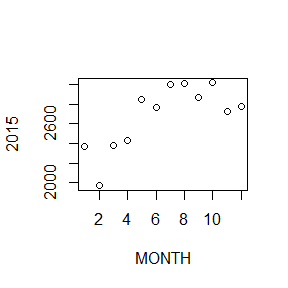

```r
plot(fars_summarize_years(2015))
```

```r
fars_summarize_years(c(2015, 2014))
```

```
## # A tibble: 12 x 3
##    MONTH `2014` `2015`
##    <int>  <int>  <int>
##  1     1   2168   2368
##  2     2   1893   1968
##  3     3   2245   2385
##  4     4   2308   2430
##  5     5   2596   2847
##  6     6   2583   2765
##  7     7   2696   2998
##  8     8   2800   3016
##  9     9   2618   2865
## 10    10   2831   3019
## 11    11   2714   2724
## 12    12   2604   2781
```

### Function `fars_map_state`

The function displays a state map plot including accidents location by year

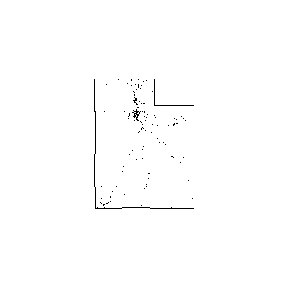

```r
state_num <- 49 # Utah
yr <- 2014
fars_map_state(state_num, yr)
```

# Links:

- [Package fars GitHub](https://github.com/EnriquePH/FARS)
- [Package fars Travis CI](https://travis-ci.org/EnriquePH/FARS)
- [Package Appveyor](https://ci.appveyor.com/project/EnriquePH/FARS)

# Fatality Analysis Reporting System (FARS)

[®γσ, Lian Hu](https://englianhu.github.io/) ®

2018-11-09

# Package Description

`fars` package reads and plots Fatality Analysis Reporting System (FARS) data from the [National Highway Traffic Safety Administration](https://www.nhtsa.gov/research-data/fatality-analysis-reporting-system-fars).

[FARS](https://en.wikipedia.org/wiki/Fatality_Analysis_Reporting_System) is a nationwide census, providing the American public yearly data, regarding fatal injuries suffered in motor vehicle traffic crashes.

## Load Packages

```r
library(farsdata)
library(maps)
```

## Included data

Data files included within the package are:

```r
list.files(system.file("extdata", package = "farsdata"))
```

```
## [1] "accident_2013.csv.bz2" "accident_2014.csv.bz2" "accident_2015.csv.bz2"
```

## Package Functions

### Function `make_filename`

This function returns file name and path to the data files:

```r
yr <- 2015
make_filename(yr)
```

```
## [1] "C:/Users/Owner/Documents/R/win-library/3.5/farsdata/extdata/accident_2015.csv.bz2"
```

### Function `fars_read_years`

Ancillary function used by `fars_summarize_years`

```r
fars_read_years(2013)
```

```
## [[1]]
## # A tibble: 30,202 x 2
##    MONTH  year
##    <int> <int>
##  1     1  2013
##  2     1  2013
##  3     1  2013
##  4     1  2013
##  5     1  2013
##  6     1  2013
##  7     1  2013
##  8     1  2013
##  9     1  2013
## 10     1  2013
## # ... with 30,192 more rows
```

### Function `fars_summarize_years`

This function summarizes yearly accidents data, by month.

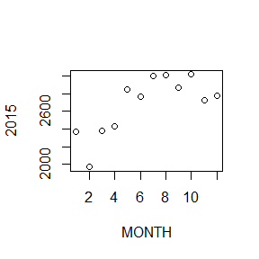

```r
plot(fars_summarize_years(2015))
```

```r
fars_summarize_years(c(2015, 2014))
```

```
## # A tibble: 12 x 3
##    MONTH `2014` `2015`
##    <int>  <int>  <int>
##  1     1   2168   2368
##  2     2   1893   1968
##  3     3   2245   2385
##  4     4   2308   2430
##  5     5   2596   2847
##  6     6   2583   2765
##  7     7   2696   2998
##  8     8   2800   3016
##  9     9   2618   2865
## 10    10   2831   3019
## 11    11   2714   2724
## 12    12   2604   2781
```

### Function `fars_map_state`

The function displays a state map plot including accidents location by year

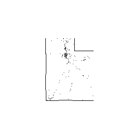

```r
state_num <- 49 # Utah
yr <- 2014
fars_map_state(state_num, yr)
```

# Links:

- [Package fars GitHub](https://github.com/EnriquePH/FARS)
- [Package fars Travis CI](https://travis-ci.org/EnriquePH/FARS)
- [Package Appveyor](https://ci.appveyor.com/project/EnriquePH/FARS)